## Do Negative Information Choices Depend on Doman and Sex?

Yes.  
Disgust domain and sex interact to predict choices in the dating game, *F*(2,2030) = 9.09, *p* = p<.001.

Controlling for relationship status, disgust senstivity, preferences, own traits, or mate value did not affect this interaction.

```
##
## Error: PIN
##             Df    Sum Sq   Mean Sq F value Pr(>F)
## sex          1 1.000e-27 1.392e-27   0.207  0.649
## Residuals 1015 6.813e-24 6.712e-27
##
## Error: Within
##              Df Sum Sq Mean Sq F value   Pr(>F)
## domain        2    543  271.29  121.65  < 2e-16 ***
## domain:sex    2     41   20.27    9.09 0.000117 ***
## Residuals  2030   4527    2.23
## ---
## Signif. codes:  0 '***' 0.001 '**' 0.01 '*' 0.05 '.' 0.1 ' ' 1
```

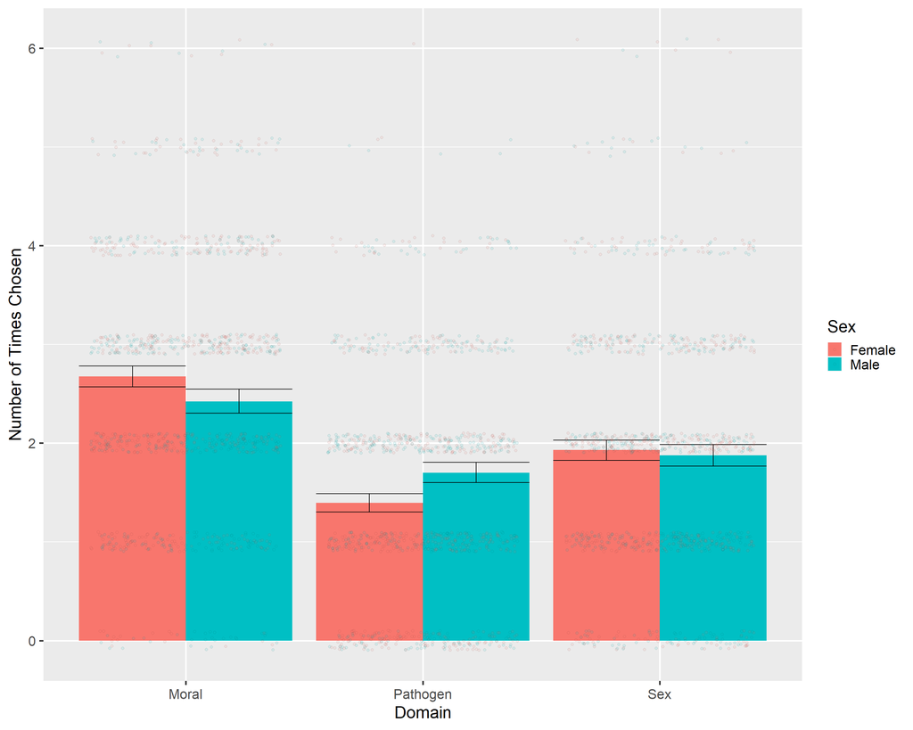

### Does this differ by country?

Not really.  
Disgust domain and country interact to predict choices in the dating game, *F*(2,2028) = 21.36, *p* = p<.001

However, the three-way interaction between disgust domain, country, and sex was not significant.

```
##
## Error: PIN
##             Df    Sum Sq   Mean Sq F value Pr(>F)
## sex          1 1.000e-27 1.392e-27   0.208  0.649
## country      1 1.100e-26 1.138e-26   1.697  0.193
## Residuals 1014 6.802e-24 6.708e-27
##
## Error: Within
##                  Df Sum Sq Mean Sq F value   Pr(>F)
## domain            2    543  271.29 124.094  < 2e-16 ***
## domain:sex        2     41   20.27   9.272 9.81e-05 ***
## domain:country    2     93   46.70  21.363 6.58e-10 ***
## Residuals      2028   4433    2.19
## ---
## Signif. codes:  0 '***' 0.001 '**' 0.01 '*' 0.05 '.' 0.1 ' ' 1
```

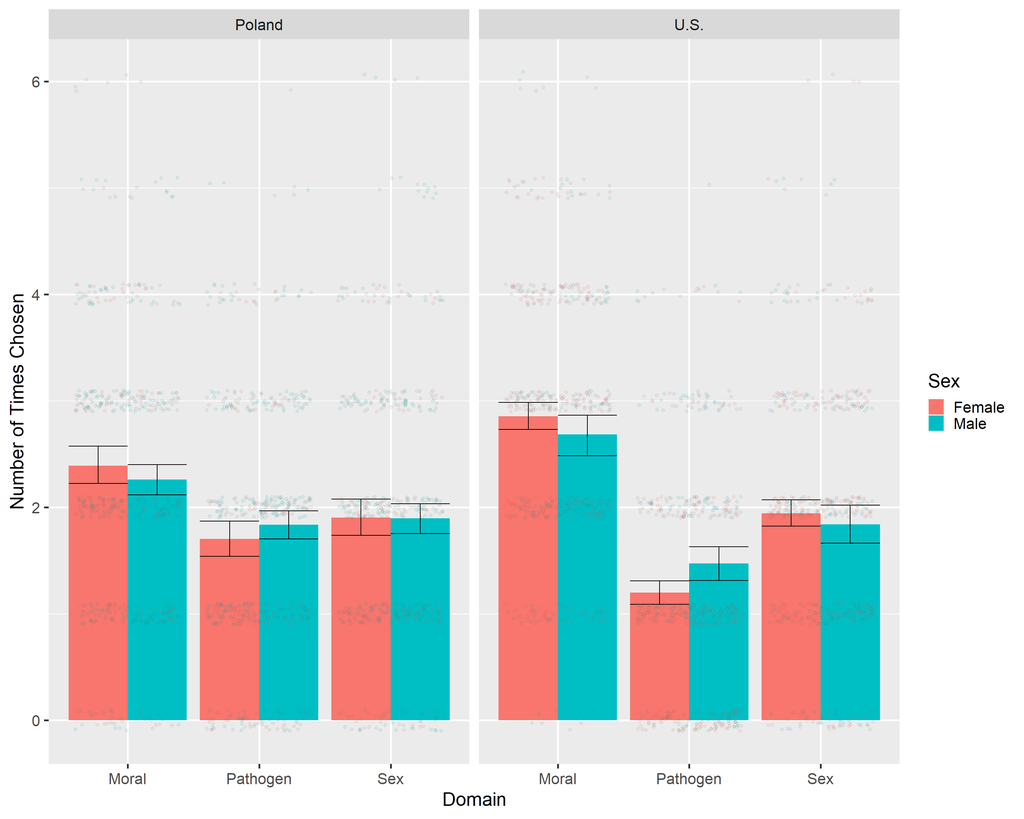

### Does this differ by sexual orientation?

Not really.  
Disgust domain and Kinsey score to predict choices in the dating game, *F*(2,2028) = 6.33, *p* = 0.002

However, the three-way interaction between disgust domain, sexual orientation, and sex was not significant.

```
##
## Error: PIN
##             Df    Sum Sq   Mean Sq F value Pr(>F)
## sex          1 1.000e-27 1.392e-27   0.207  0.649
## kinsey       1 6.000e-27 5.580e-27   0.831  0.362
## Residuals 1014 6.807e-24 6.713e-27
##
## Error: Within
##                 Df Sum Sq Mean Sq F value   Pr(>F)
## domain           2    543  271.29 122.292  < 2e-16 ***
## domain:sex       2     41   20.27   9.137 0.000112 ***
## domain:kinsey    2     28   14.03   6.325 0.001826 **
## Residuals     2028   4499    2.22
## ---
## Signif. codes:  0 '***' 0.001 '**' 0.01 '*' 0.05 '.' 0.1 ' ' 1
```

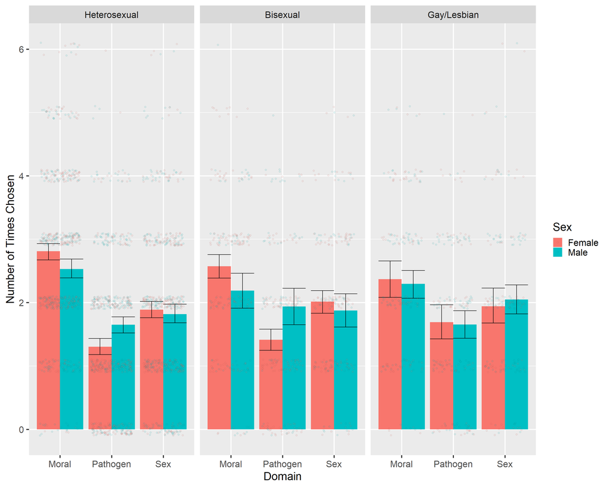

### Does disgust sensitivity predict game choices?

Yes.

For all domains, greater disgust sensitivity predicts less frequently choosing that domain

Moral Disgust Sensitivity:

```
##
## Call:
## lm(formula = choiceMoral ~ tddMoral + tddPath + tddSex, data = data)
##
## Residuals:
##     Min      1Q  Median      3Q     Max
## -2.7737 -0.7271 -0.0095  0.6658  3.8731
##
## Coefficients:
##             Estimate Std. Error t value Pr(>|t|)
## (Intercept)  2.67137    0.14902  17.926  < 2e-16 ***
## tddMoral    -0.12253    0.03842  -3.189  0.00147 **
## tddPath      0.13411    0.04268   3.142  0.00173 **
## tddSex      -0.05515    0.03386  -1.629  0.10368
## ---
## Signif. codes:  0 '***' 0.001 '**' 0.01 '*' 0.05 '.' 0.1 ' ' 1
##
## Residual standard error: 1.272 on 1013 degrees of freedom
## Multiple R-squared:  0.0173, Adjusted R-squared:  0.01439
## F-statistic: 5.944 on 3 and 1013 DF,  p-value: 0.0005107
```

Pathogen Disgust Sensitivity:

```
##
## Call:
## lm(formula = choicePath ~ tddMoral + tddPath + tddSex, data = data)
##
## Residuals:
##     Min      1Q  Median      3Q     Max
## -2.4151 -0.7522 -0.1812  0.6242  4.0981
##
## Coefficients:
##             Estimate Std. Error t value Pr(>|t|)
## (Intercept)  1.62231    0.13155  12.332  < 2e-16 ***
## tddMoral     0.08165    0.03392   2.407   0.0163 *
## tddPath     -0.24184    0.03768  -6.419 2.10e-10 ***
## tddSex       0.17739    0.02989   5.935 4.02e-09 ***
## ---
## Signif. codes:  0 '***' 0.001 '**' 0.01 '*' 0.05 '.' 0.1 ' ' 1
##
## Residual standard error: 1.123 on 1013 degrees of freedom
## Multiple R-squared:  0.05647,    Adjusted R-squared:  0.05367
## F-statistic: 20.21 on 3 and 1013 DF,  p-value: 1.007e-12
```

Sexual Disgust Sensitivity:

```
##
## Call:
## lm(formula = choiceSex ~ tddMoral + tddPath + tddSex, data = data)
##
## Residuals:
##     Min      1Q  Median      3Q     Max
## -2.3313 -0.8925  0.0078  0.9419  4.2217
##
## Coefficients:
##             Estimate Std. Error t value Pr(>|t|)
## (Intercept)  1.70632    0.14369  11.875  < 2e-16 ***
## tddMoral     0.04088    0.03705   1.104 0.270067
## tddPath      0.10773    0.04115   2.618 0.008979 **
## tddSex      -0.12225    0.03265  -3.745 0.000191 ***
## ---
## Signif. codes:  0 '***' 0.001 '**' 0.01 '*' 0.05 '.' 0.1 ' ' 1
##
## Residual standard error: 1.226 on 1013 degrees of freedom
## Multiple R-squared:  0.01604,    Adjusted R-squared:  0.01313
## F-statistic: 5.506 on 3 and 1013 DF,  p-value: 0.0009425
```

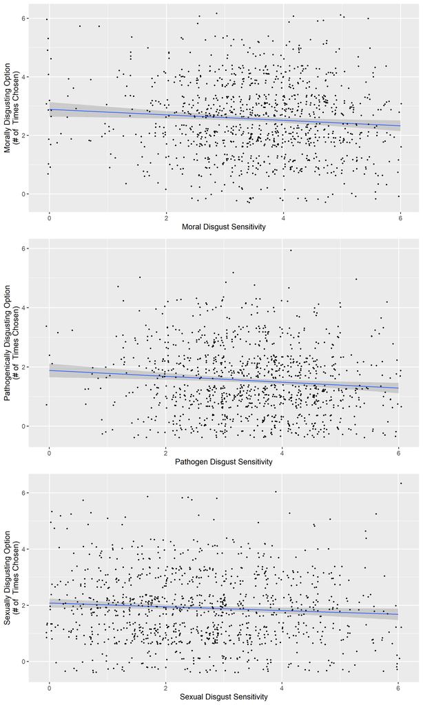

## Do Positive Information Choices Depend on Doman and Sex?

Yes.  
Trait and sex interact to predict choices in the dating game, *F*(4,4060) = 4.27, *p* = 0.002

Controlling for relationship status, disgust senstivity, preferences, own traits, or mate value did not affect this interaction.

```
##
## Error: PIN
##             Df    Sum Sq   Mean Sq F value  Pr(>F)
## sex          1 1.160e-25 1.163e-25   8.762 0.00315 **
## Residuals 1015 1.347e-23 1.327e-26
## ---
## Signif. codes:  0 '***' 0.001 '**' 0.01 '*' 0.05 '.' 0.1 ' ' 1
##
## Error: Within
##             Df Sum Sq Mean Sq F value Pr(>F)
## trait        4    416  103.89  71.671 <2e-16 ***
## trait:sex    4     25    6.19   4.269 0.0019 **
## Residuals 4060   5885    1.45
## ---
## Signif. codes:  0 '***' 0.001 '**' 0.01 '*' 0.05 '.' 0.1 ' ' 1
```

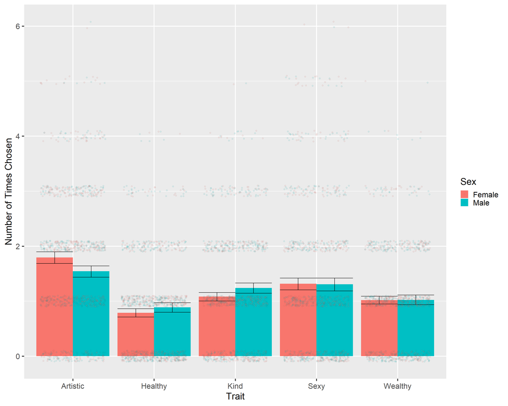

### Does this differ by country?

Not really.  
Trait and country interact to predict choices in the dating game, *F*(4,4056) = 20.47, *p* = p<.001

However, the three-way interaction between trait, country, and sex was not significant.

```
##
## Error: PIN
##             Df    Sum Sq   Mean Sq F value  Pr(>F)
## sex          1 1.160e-25 1.163e-25   8.779 0.00312 **
## country      1 4.000e-26 3.996e-26   3.017 0.08269 .
## Residuals 1014 1.343e-23 1.324e-26
## ---
## Signif. codes:  0 '***' 0.001 '**' 0.01 '*' 0.05 '.' 0.1 ' ' 1
##
## Error: Within
##                 Df Sum Sq Mean Sq F value  Pr(>F)
## trait            4    416  103.89  73.046 < 2e-16 ***
## trait:sex        4     25    6.19   4.351 0.00164 **
## trait:country    4    116   29.11  20.468 < 2e-16 ***
## Residuals     4056   5769    1.42
## ---
## Signif. codes:  0 '***' 0.001 '**' 0.01 '*' 0.05 '.' 0.1 ' ' 1
```

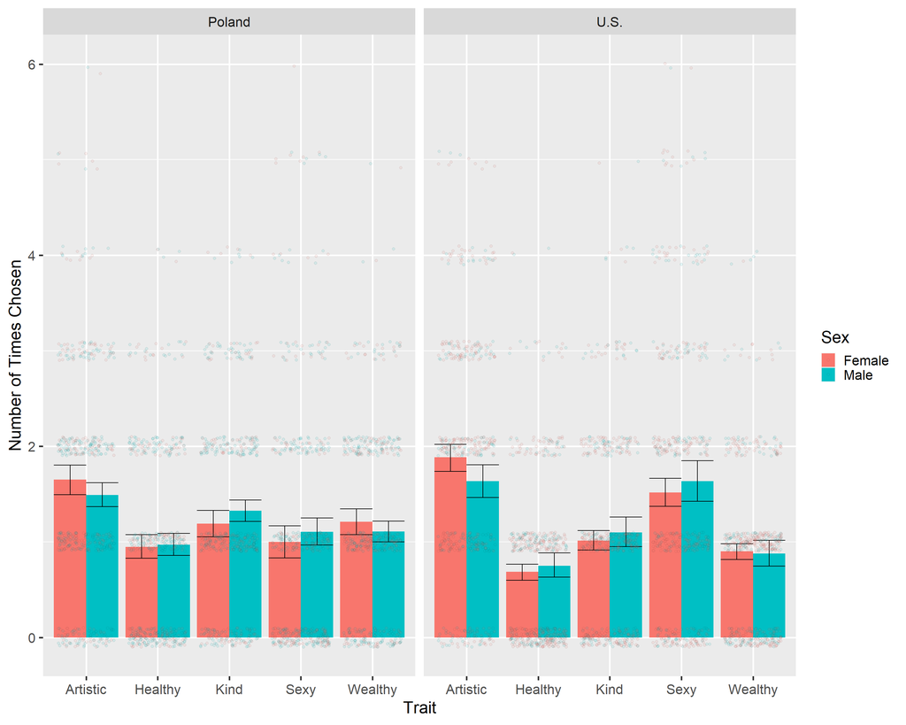

### Does this differ by sexual orientation?

Yes  
Trait, Kinsey score, and sex interacted to predict choices in the dating game, *F*(4,4052) = 4.51, *p* = 0.001

```
##
## Error: PIN
##              Df    Sum Sq   Mean Sq F value  Pr(>F)
## sex           1 1.160e-25 1.163e-25   8.745 0.00318 **
## kinsey        1 0.000e+00 2.000e-28   0.015 0.90258
## sex:kinsey    1 0.000e+00 2.100e-28   0.016 0.90009
## Residuals  1013 1.347e-23 1.330e-26
## ---
## Signif. codes:  0 '***' 0.001 '**' 0.01 '*' 0.05 '.' 0.1 ' ' 1
##
## Error: Within
##                    Df Sum Sq Mean Sq F value  Pr(>F)
## trait               4    416  103.89  72.013 < 2e-16 ***
## trait:sex           4     25    6.19   4.289 0.00183 **
## trait:kinsey        4     13    3.36   2.329 0.05381 .
## trait:sex:kinsey    4     26    6.51   4.510 0.00123 **
## Residuals        4052   5846    1.44
## ---
## Signif. codes:  0 '***' 0.001 '**' 0.01 '*' 0.05 '.' 0.1 ' ' 1
```

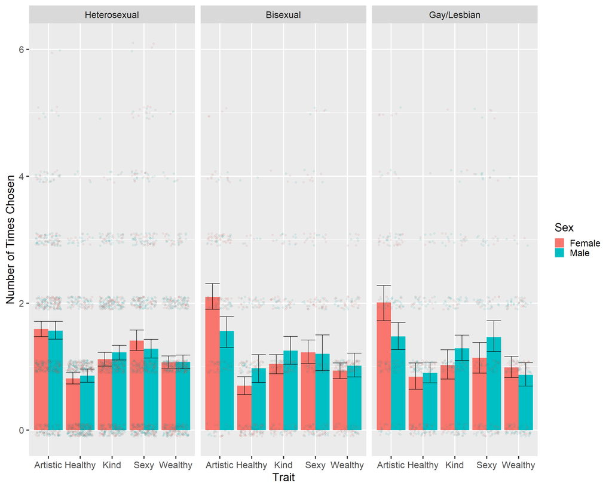

### Do own traits predict the traits chosen?

For some.

People who rated themselves higher in artistic ability (*b* = 0.0968174, *p* = p<.001) or sexiness (*b* = 0.0462741, *p* = 0.039) were more likely to choose these traits. However, people who rated themselves higher in kindness were *less* likely to choose kindness options (*b* = -0.0368813, *p* = 0.032). However, this does not replicate with the more conservative exclusion criteria.

Artistic ability:

```
##
## Call:
## lm(formula = choiceArt ~ selfArt + selfHealth + selfKind + selfSexy +
##     selfResources, data = data)
##
## Residuals:
##     Min      1Q  Median      3Q     Max
## -2.5934 -0.8126 -0.0569  0.7218  4.1228
##
## Coefficients:
##                Estimate Std. Error t value Pr(>|t|)
## (Intercept)    1.745930   0.176508   9.892  < 2e-16 ***
## selfArt        0.096817   0.016464   5.880 5.56e-09 ***
## selfHealth    -0.076046   0.020910  -3.637 0.000290 ***
## selfKind       0.037729   0.020279   1.861 0.063102 .
## selfSexy      -0.072380   0.020447  -3.540 0.000419 ***
## selfResources  0.007104   0.020476   0.347 0.728714
## ---
## Signif. codes:  0 '***' 0.001 '**' 0.01 '*' 0.05 '.' 0.1 ' ' 1
##
## Residual standard error: 1.183 on 1011 degrees of freedom
## Multiple R-squared:  0.05698,    Adjusted R-squared:  0.05232
## F-statistic: 12.22 on 5 and 1011 DF,  p-value: 1.615e-11
```

Sexiness:

```
##
## Call:
## lm(formula = choiceSexy ~ selfArt + selfHealth + selfKind + selfSexy +
##     selfResources, data = data)
##
## Residuals:
##     Min      1Q  Median      3Q     Max
## -1.7697 -1.1409 -0.2913  0.6993  4.7339
##
## Coefficients:
##               Estimate Std. Error t value Pr(>|t|)
## (Intercept)    0.85294    0.19355   4.407 1.16e-05 ***
## selfArt       -0.01751    0.01805  -0.970  0.33221
## selfHealth     0.06640    0.02293   2.896  0.00386 **
## selfKind       0.03219    0.02224   1.448  0.14805
## selfSexy       0.04627    0.02242   2.064  0.03928 *
## selfResources -0.06703    0.02245  -2.985  0.00290 **
## ---
## Signif. codes:  0 '***' 0.001 '**' 0.01 '*' 0.05 '.' 0.1 ' ' 1
##
## Residual standard error: 1.297 on 1011 degrees of freedom
## Multiple R-squared:  0.02361,    Adjusted R-squared:  0.01878
## F-statistic: 4.889 on 5 and 1011 DF,  p-value: 0.0001996
```

Kindness:

```
##
## Call:
## lm(formula = choiceKind ~ selfArt + selfHealth + selfKind + selfSexy +
##     selfResources, data = data)
##
## Residuals:
##     Min      1Q  Median      3Q     Max
## -1.4798 -1.0670 -0.1407  0.8037  3.9368
##
## Coefficients:
##                Estimate Std. Error t value Pr(>|t|)
## (Intercept)    1.276706   0.149427   8.544   <2e-16 ***
## selfArt       -0.009373   0.013938  -0.672   0.5014
## selfHealth     0.005000   0.017702   0.282   0.7777
## selfKind      -0.036881   0.017167  -2.148   0.0319 *
## selfSexy       0.014430   0.017310   0.834   0.4047
## selfResources  0.013194   0.017334   0.761   0.4467
## ---
## Signif. codes:  0 '***' 0.001 '**' 0.01 '*' 0.05 '.' 0.1 ' ' 1
##
## Residual standard error: 1.001 on 1011 degrees of freedom
## Multiple R-squared:  0.006107,   Adjusted R-squared:  0.001191
## F-statistic: 1.242 on 5 and 1011 DF,  p-value: 0.2871
```

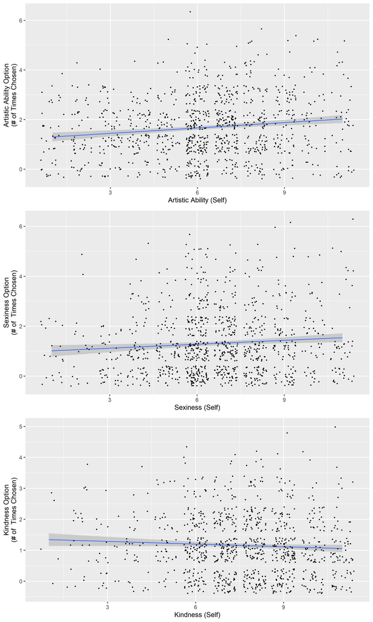